# Example for Version 2 of Paper

I would like to create a new example that is realistic but still simple enought that it can be verified manually.

Begin by clearing the workspace:

Next, load the packages needed for this:

Load geography:

Create simple features objects for population centers and clinics:

```r
# Clinics
sim_clinics <- st_sf(Clinics_data, geometry_clinics, stringsAsFactors = TRUE)
# Population centers
sim_population <- st_sf(Population_data, geometry_population, stringsAsFactors = TRUE)
```

Calculate the distance between these points as a measure of cost:

```r
distance_matrix <- round(pointDistance(st_coordinates(sim_population),
                                 st_coordinates(sim_clinics),
                                 type='Euclidean', lonlat = FALSE))
```

```r
# Clinic
clinic_buffers_1 <- st_buffer(sim_clinics, quantile(as.vector(distance_matrix), probs = c(0, 1/10, 3/10, 5/10, 7/10, 8/10, 9/10))[5])
clinic_buffers_2 <- st_buffer(sim_clinics, quantile(as.vector(distance_matrix), probs = c(0, 1/10, 3/10, 5/10, 7/10, 8/10, 9/10))[3])
clinic_buffers_3 <- st_buffer(sim_clinics, quantile(as.vector(distance_matrix), probs = c(0, 1/10, 3/10, 5/10, 7/10, 8/10, 9/10))[1])
# Population centers
population_buffers <- st_buffer(sim_population, quantile(as.vector(distance_matrix), probs = c(0, 1/10, 3/10, 5/10, 7/10, 8/10, 9/10))[4])
```

Plot the first stage of the 2SFCA algorithm (i.e., clinic catchments):

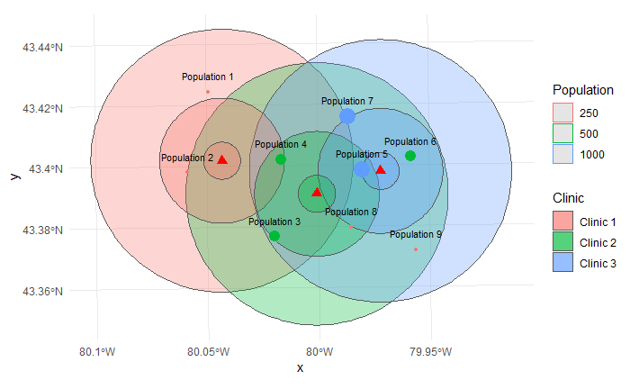

```r
ggplot() +
  geom_sf(data = clinic_buffers_1, aes(fill = id), alpha = 0.3) +
  geom_sf(data = clinic_buffers_2, aes(fill = id), alpha = 0.3) +
  geom_sf(data = clinic_buffers_3, aes(fill = id), alpha = 0.3) +
  geom_sf(data = sim_population, aes(size = Population, color = as.factor(Population))) +
  scale_size(guide = FALSE) +
  guides(fill = guide_legend(title = "Clinic"), color=guide_legend(title="Population")) +
  geom_sf_text(data = sim_population, aes(label = id), vjust = -1.5, size = 3) +
  geom_sf(data = sim_clinics, shape = 17, color = "red", size = 3)+
  theme_minimal()
```

```r
# Quantiles according to distance
quantiles_d <- quantile(as.vector(distance_matrix), probs = c(0, 1/10, 3/10, 5/10, 7/10, 8/10, 9/10))
impedance_binary <- 1 * (distance_matrix <= quantile(as.vector(distance_matrix), probs = c(0, 1/10, 3/10, 5/10, 7/10, 8/10, 9/10))[5])
impedance_stepwise <- 0.945 * (distance_matrix <= quantiles_d[1]) +
  0.600 * (distance_matrix > quantiles_d[1] & distance_matrix <= quantiles_d[3]) +
  0.242 * (distance_matrix > quantiles_d[3] & distance_matrix <= quantiles_d[5]) +
  0 * (distance_matrix > quantiles_d[5])

kable(data.frame(Center = Population_data$id, impedance_binary, impedance_stepwise),
      "html",
      col.names = c("Population Center",
                           "Clinic 1",
                           "Clinic 2",
                           "Clinic 3",
                           "Clinic 1",
                           "Clinic 2",
                           "Clinic 3")) %>%
  add_header_above(c(" " = 1, "Binary Impedance" = 3, "Stepwise Impedance" = 3))
```

[output not shown]

| Population Center | Binary Impedance Clinic 1 | Binary Impedance Clinic 2 | Binary Impedance Clinic 3 | Stepwise Impedance Clinic 1 | Stepwise Impedance Clinic 2 | Stepwise Impedance Clinic 3 |
| --- | --- | --- | --- | --- | --- | --- |
| Population 1 | 1 | 0 | 0 | 0.242 | 0.000 | 0.000 |
| Population 2 | 1 | 1 | 0 | 0.600 | 0.242 | 0.000 |
| Population 3 | 1 | 1 | 1 | 0.242 | 0.600 | 0.242 |
| Population 4 | 1 | 1 | 1 | 0.600 | 0.600 | 0.242 |
| Population 5 | 0 | 1 | 1 | 0.000 | 0.600 | 0.945 |
| Population 6 | 0 | 1 | 1 | 0.000 | 0.242 | 0.600 |
| Population 7 | 0 | 1 | 1 | 0.000 | 0.242 | 0.242 |
| Population 8 | 0 | 1 | 1 | 0.000 | 0.600 | 0.242 |
| Population 9 | 0 | 1 | 1 | 0.000 | 0.242 | 0.242 |

The demand can be calculated as:

```r
demand_binary <- (t(impedance_binary) %*% (sim_population$Population))
demand_stepwise <- (t(impedance_stepwise) %*% (sim_population$Population))
kable(data.frame(Clinic = c("Clinic 1", "Clinic 2", "Clinic 3"),
                 demand_binary = demand_binary,
                 demand_stepwise = demand_stepwise),
      digits = 3,
      "html",
      col.names = c("Clinic",
                    "Demand (Binary)",
                    "Demand (Stepwise)"))
```

| Clinic | Demand (Binary) | Demand (Stepwise) |
| --- | --- | --- |
| Clinic 1 | 1500 | 631.5 |
| Clinic 2 | 4250 | 1834.0 |
| Clinic 3 | 4000 | 1850.0 |

It can be seen that the total population in this system is 4500 and yet, the assumed level of demand is 9750. This is because the algorithm assumes that every person can potentially attend more than one clinic. This tends to inflate the demand for the service.

Calculate row and column adjusted-impedance:

```r
#Row standardize the impedance matrix to ensure that the sum of the population over the clinics preserves the population totals
row_sums_binary <- rowSums(impedance_binary) #sum weights over rows
row_sums_binary[row_sums_binary == 0] <- 1 #change to one for those rows where the total is zero to avoid divisions by zero
impedance_binary_row_adjusted <- sweep(impedance_binary, 1, row_sums_binary, FUN = "/") #row standardize
#Column standardize the impedance matrix to ensure that the sum of the level of service preserves the total supply
col_sums_binary <- colSums(impedance_binary) #sum weights over rows
col_sums_binary[col_sums_binary == 0] <- 1 #change to one for those rows where the total is zero to avoid divisions by zero
impedance_binary_col_adjusted <- sweep(impedance_binary, 2, col_sums_binary, FUN = "/") #column standardize
kable(data.frame(Center = Population_data$id, impedance_binary_row_adjusted, impedance_binary_col_adjusted),
      "html",
      digits = 3,
      col.names = c("Population Center",
                           "Clinic 1",
                           "Clinic 2",
                           "Clinic 3",
                           "Clinic 1",
                           "Clinic 2",
                           "Clinic 3")) %>%
  add_header_above(c(" " = 1, "Row Standardized" = 3, "Column Standardized" = 3))
```

[output not shown]

| Population Center | Row Standardized Clinic 1 | Row Standardized Clinic 2 | Row Standardized Clinic 3 | Column Standardized Clinic 1 | Column Standardized Clinic 2 | Column Standardized Clinic 3 |
| --- | --- | --- | --- | --- | --- | --- |
| Population 1 | 1.000 | 0.000 | 0.000 | 0.25 | 0.000 | 0.000 |
| Population 2 | 0.500 | 0.500 | 0.000 | 0.25 | 0.125 | 0.000 |
| Population 3 | 0.333 | 0.333 | 0.333 | 0.25 | 0.125 | 0.143 |
| Population 4 | 0.333 | 0.333 | 0.333 | 0.25 | 0.125 | 0.143 |
| Population 5 | 0.000 | 0.500 | 0.500 | 0.00 | 0.125 | 0.143 |
| Population 6 | 0.000 | 0.500 | 0.500 | 0.00 | 0.125 | 0.143 |
| Population 7 | 0.000 | 0.500 | 0.500 | 0.00 | 0.125 | 0.143 |
| Population 8 | 0.000 | 0.500 | 0.500 | 0.00 | 0.125 | 0.143 |
| Population 9 | 0.000 | 0.500 | 0.500 | 0.00 | 0.125 | 0.143 |

The 3SFCA of Wan et al. (2012) uses a selection weight to adjust the population. The selection weights are essentially a row-standardized matrix of weights. They can be based on the cost matrix, as follows (using a negative exponential function to calculate the weights):

```r
selection_weights <- exp(-0.0000001 * distance_matrix^2)
```

Moreover, the selection weights apply only to centers that are within the catchment zone, as per the impedance function:

```r
selection_weights <- selection_weights * impedance_binary
```

Finally, the selection weights are standardized so that the sum of the rows is one:

$$G_{ij}=\frac{T(d_{ij})}{\sum_jT(d_{ij})}$$

```r
row_sums_binary <- rowSums(selection_weights) #sum weights over rows
row_sums_binary[row_sums_binary == 0] <- 1 #change to one for those rows where the total is zero to avoid divisions by zero
selection_weights <- sweep(selection_weights, 1, row_sums_binary, FUN = "/") #row standardize
kable(data.frame(Center = Population_data$id, selection_weights),
      "html",
      digits = 3,
      col.names = c("Population Center",
                           "Clinic 1",
                           "Clinic 2",
                           "Clinic 3"))
```

| Population Center | Clinic 1 | Clinic 2 | Clinic 3 |
| --- | --- | --- | --- |
| Population 1 | 1.000 | 0.000 | 0.000 |
| Population 2 | 0.891 | 0.109 | 0.000 |
| Population 3 | 0.299 | 0.581 | 0.120 |
| Population 4 | 0.386 | 0.449 | 0.166 |
| Population 5 | 0.000 | 0.425 | 0.575 |
| Population 6 | 0.000 | 0.230 | 0.770 |
| Population 7 | 0.000 | 0.406 | 0.594 |
| Population 8 | 0.000 | 0.555 | 0.445 |
| Population 9 | 0.000 | 0.325 | 0.675 |

The level of service is calculated as follows:

```r
demand_selection_binary <- (t(selection_weights * impedance_binary) %*% (sim_population$Population))
demand_selection_stepwise <- (t(selection_weights * impedance_stepwise) %*% (sim_population$Population))
kable(data.frame(Clinic = c("Clinic 1", "Clinic 2", "Clinic 3"),
                 demand_selection_binary = demand_selection_binary,
                 demand_selection_stepwise = demand_selection_stepwise),
      digits = 3,
      "html",
      col.names = c("Clinic",
                    "Demand (Binary)",
                    "Demand (Stepwise)"))
```

| Clinic | Demand (Binary) | Demand (Stepwise) |
| --- | --- | --- |
| Clinic 1 | 815.061 | 346.018 |
| Clinic 2 | 1708.103 | 799.286 |
| Clinic 3 | 1976.836 | 1020.698 |